# Homework 10

Mia Murphy

4/29/2021

### Using a for loop, write a function to calculate the number of zeroes in a numeric vector. Before entering the loop, set up a counter variable counter <- 0. Inside the loop, add 1 to counter each time you have a zero in the matrix. Finally, use return(counter) for the output.

```r
library(dplyr)
abc <- rbinom(15, 4, 0.1)
my_loop <- function(a=abc) {
counter <- 0
 for(i in seq_along(a)) {
  if(a[i] == 0) {
    counter <- counter + 1
  }}
    return(counter)
}

print(my_loop())
```

```
## [1] 9
```

```r
abc
```

```
##  [1] 0 0 2 1 0 0 2 0 1 0 0 1 1 0 0
```

### Use subsetting instead of a loop to rewrite the function as a single line of code.

```r
newabc <- rbinom(15, 4, 0.1)

counting <- function(a=newabc) {
  checkzero <- length(a[a==0])
  return(checkzero)
}

counting()
```

```
## [1] 12
```

```r
newabc
```

```
##  [1] 1 0 0 0 0 1 0 0 0 0 0 0 0 2 0
```

### Write a function that takes as input two integers representing the number of rows and columns in a matrix. The output is a matrix of these dimensions in which each element is the product of the row number x the column number.

```r
matrixtime <- function(rows = 3, cols = 3) {

  my_matrix <- matrix(data = NA, nrow = rows, ncol = cols)
  for(i in 1:rows) {
  for(j in 1:cols) {
    my_matrix[i,j] <-  i * j
  }
}
    return(my_matrix)
}

matrixtime()
```

```
##      [,1] [,2] [,3]
## [1,]    1    2    3
## [2,]    2    4    6
## [3,]    3    6    9
```

### Use the code from the April 8th lecture (Randomization Tests) to design and conduct a randomization test for some of your own data. You will need to modify the functions that read in the data, calculate the metric, and randomize the data. Once those are set up, the program should run correctly calling your new functions. Also, to make your analysis fully repeatable, make sure you set the random number seed at the beginning (use either set.seed() in base R, or char2seed in the TeachingDemos package

```r
library(TeachingDemos)
```

```r
library(ggplot2)
set.seed(1000)

#Fake data from before

preybison <- rnorm(n=20, mean=2500, sd=500)
filler <- rnorm(n=20, sd=3)
wolfpack <- 2 + preybison * 0.01 + filler

newdata <- function(z=NULL) {
  if(is.null(z)) {
    x_obs <- preybison
    y_obs <- wolfpack
    df <- data.frame(ID=seq_along(x_obs),
                     x_obs,
                     y_obs)}
  return(df)

}

newdata()
```

```
##    ID    x_obs    y_obs
## 1   1 2277.111 32.78132
## 2   2 1897.072 17.28967
## 3   3 2520.563 29.70837
## 4   4 2819.694 31.79466
## 5   5 2106.723 21.12675
## 6   6 2307.255 26.88204
## 7   7 2262.066 19.26913
## 8   8 2859.875 31.60358
## 9   9 2490.747 28.59040
## 10 10 1813.441 23.79722
## 11 11 2008.786 21.45350
## 12 12 2222.756 26.32585
## 13 13 2560.691 25.48760
## 14 14 2439.564 25.00019
## 15 15 1831.979 15.02120
## 16 16 2585.029 28.41815
## 17 17 2577.539 26.67685
## 18 18 2512.466 30.29746
## 19 19 1476.707 14.54221
## 20 20 2606.577 24.02069
```

```r
#metric

themetric <- function(z = NULL) {
  if(is.null(z)){
    xobs <- preybison
    yobs <- wolfpack
    z <- data.frame(ID=seq_along(xobs),
                    xobs,
                    yobs)}
  . <-lm(z[,3] ~ z[,2])
  . <- summary(.)
  . <- .$coefficients[2,1]
  slope <- .

return(slope)
}
themetric()
```

```
## [1] 0.01212578
```

```r
#random

randomdat <- function(z=NULL){
  if(is.null(z)){
    xobs <- preybison
    yobs <- wolfpack
    z <- data.frame(ID=seq_along(xobs),
                    xobs,
                    yobs)}
  z[,3] <- sample(z[,3])
  return(z)
}

randomdat()
```

```
##    ID     xobs     yobs
## 1   1 2277.111 15.02120
## 2   2 1897.072 26.32585
## 3   3 2520.563 26.88204
## 4   4 2819.694 28.59040
## 5   5 2106.723 30.29746
## 6   6 2307.255 21.12675
## 7   7 2262.066 21.45350
## 8   8 2859.875 24.02069
## 9   9 2490.747 25.00019
## 10 10 1813.441 23.79722
## 11 11 2008.786 14.54221
## 12 12 2222.756 32.78132
## 13 13 2560.691 29.70837
## 14 14 2439.564 26.67685
## 15 15 1831.979 19.26913
## 16 16 2585.029 28.41815
## 17 17 2577.539 25.48760
## 18 18 2512.466 17.28967
## 19 19 1476.707 31.79466
## 20 20 2606.577 31.60358
```

```r
#p value
p_val1 <- function(z=NULL) {
  if(is.null(z)){
    xobs <- preybison
    yobs <- wolfpack
    z <- data.frame(ID=seq_along(xobs),
                    xobs,
                    yobs)}
  z[,3] <- sample(z[,3])
  . <- lm(z[,3] ~ z[,2])
  . <- summary(.)
  . <- .$coefficients[2,4]
  p_val2 <- .
  return(p_val2)
}

p_val1()
```

```
## [1] 0.9309479
```

```r
#lower and upper p value lupval

lupval <- function(z = NULL) {
  if(is.null(z)){
    z <- list(xobs = runif(1), x_sim = runif(1000)) }
  lowerp <- mean(z[[2]] <= z[[1]])
  upperp <- mean(z[[2]] >= z[[1]])

  return(c(pl = lowerp,  pu = upperp))
}

lupval()
```

```
##    pl    pu
## 0.723 0.277
```

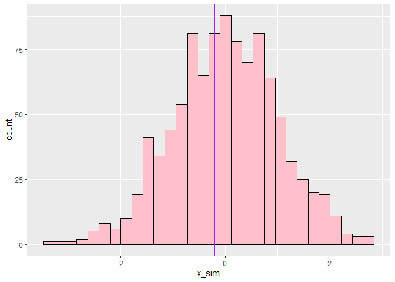

```r
library(ggplot2)

plotrtest <- function(z = NULL) {
  if(is.null(z)){
    z <- list(rnorm(1), rnorm(1000)) }

  df <- data.frame(ID = seq_along(z[[2]]), x_sim = z[[2]])
  p_1 <- ggplot(data = df, mapping = aes(x = x_sim))
  p_1 + geom_histogram(mapping=aes(fill = I("pink"), color = I("black"))) +
    geom_vline(aes(xintercept = z[[1]], col = "purple"))

}

plotrtest()
```

```r
set.seed(100)

n_sim <- 10000

x_sim <- rep(NA, n_sim)

df <- newdata()

x_obs <- themetric(df)

for (i in seq_len(n_sim)) {
  x_sim[i] <- themetric(randomdat(df))
}

slopes <- list(x_obs, x_sim)

lupval(z = slopes)
```

```
## pl pu
##  1  0
```

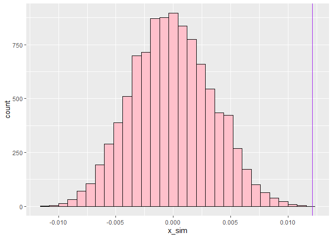

```r
plotrtest(slopes)
```

```r
checkfinal <- lm(x_obs~y_obs, data=df)
```

```r
summary(checkfinal)
```

```
##
## Call:
## lm(formula = x_obs ~ y_obs, data = df)
##
## Residuals:
##     Min      1Q  Median      3Q     Max
## -445.53 -103.89    1.47  157.10  350.08
##
## Coefficients:
##             Estimate Std. Error t value Pr(>|t|)
## (Intercept)   978.38     237.74   4.115  0.00065 ***
## y_obs          53.21       9.30   5.721    2e-05 ***
## ---
## Signif. codes:  0 '***' 0.001 '**' 0.01 '*' 0.05 '.' 0.1 ' ' 1
##
## Residual standard error: 221 on 18 degrees of freedom
## Multiple R-squared:  0.6452, Adjusted R-squared:  0.6255
## F-statistic: 32.73 on 1 and 18 DF,  p-value: 2.005e-05
```